# Homework 9/10

Ben Ridenhour

09-Dec-2021

# Chapter 9

You were asked to problems 9.3.1, 9.3.2, and 9.3.5 in the book. The problems revolve around using decision theory to decide a strategy.

## Problem 9.3.1

The game is as follows:

1. A wheel is divided into 4 sections worth $0, $4, $6, and $10.
2. A player is given 3 spins and may take the value on the wheel at anytime and stop.

In the example in the book, landing in any of the sections is equiprobable. The book argues that you should take the spin whose value exceeds the *expected* value (i.e., mean value) at the uncertainty nodes. The two problems present 2 alternative probability scenarios; I also asked you to consider some measure/criterion other than the expectation to evaluate the games. In 9.3.1 the probability of landing in the $0, $4, $5, and $10 sections are 0.23, 0.37, 0.15, and 0.25, respectively.

To find the expected value of the “spin 3” uncertainty node, we simply calculate the mean, which is:

```r
ev.spin3 <- sum(c(0,4,6,10) * c(0.23, 0.37, 0.15, 0.25))
ev.spin3
```

```
## [1] 4.88
```

Next we calculate the expected value of the “spin 2” node. We do this by deciding at which sectors we stop and at which we continue to spin. If we follow the rule of “the value in hand is higher than the expected value of the next spin” rule, we would stop if a $10 or a $6 was the result. Thus the expected value is:

```r
ev.spin2 <- sum(c(ev.spin3,6,10) * c(0.6, 0.15, 0.25))
ev.spin2
```

```
## [1] 6.328
```

Finally, we calculate the expected value at spin 1. We apply the same rule as before which dictates that we only accept $10 as a result because all other outcomes are less than the expected value of spin 2. The expected value of spin 1 is:

```r
ev.spin1 <- sum(c(ev.spin2,10) * c(0.75, 0.25))
ev.spin1
```

```
## [1] 7.246
```

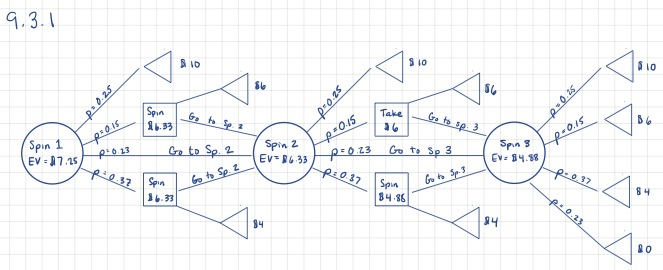

Decision tree for 9.3.1 using maximum expected value

### Applying Another Criteria: maximax

Let’s say we don’t like to play by the rules set forth in the book. What is another reasonable strategy? One might simply be to only take the maximum winning value ($10); this is the same as a maximax strategy. If we apply this criteria we would get the following expected values:

```r
m.spin3 <- sum(c(0,4,6,10) * c(0.23, 0.37, 0.15, 0.25))
m.spin3
```

```
## [1] 4.88
```

```r
m.spin2 <- sum(c(m.spin3,10) * c(0.75, 0.25))
m.spin2
```

```
## [1] 6.16
```

```r
m.spin1 <- sum(c(m.spin2,10) * c(0.75, 0.25))
m.spin1
```

```
## [1] 7.12
```

We can see that the expectations aren’t really much different using this decision rule than the “expectation” rule. That might lead you to the question of whether one strategy is more variable than the other. Recall that given weights $w_i$, the variance is simply $V = \sum_i w_i(x_i-\bar{x})^2$. We can easily do this as well:

```r
vm.spin3 <- sum(c(0.23, 0.37, 0.15, 0.25) * (c(0,4,6,10)-m.spin3)^2)
vm.spin3
```

```
## [1] 12.5056
```

```r
vm.spin2 <- sum(c(0.75, 0.25) * (c(m.spin3,10)-m.spin2)^2)
vm.spin2
```

```
## [1] 4.9152
```

```r
vm.spin1 <- sum(c(0.75, 0.25) * (c(m.spin2,10)-m.spin1)^2)
vm.spin1
```

```
## [1] 2.7648
```

Compare that with:

```r
ve.spin3 <- sum(c(0.23, 0.37, 0.15, 0.25) * (c(0,4,6,10)-ev.spin3)^2)
ve.spin3
```

```
## [1] 12.5056
```

```r
ve.spin2 <- sum(c(0.6, 0.15, 0.25) * (c(ev.spin3,6,10)-ev.spin2)^2)
ve.spin2
```

```
## [1] 4.645056
```

```r
ve.spin1 <- sum(c(0.75, 0.25) * (c(ev.spin2,10)-ev.spin1)^2)
ve.spin1
```

```
## [1] 2.528172
```

The variances show that the using the “expectation” rule is slightly less variable than the “only take the max” (maximax) rule.

### Another criteria: maximin

Here’s a quick diagram showing the maximin criteria applied to the same problem. Notice that, being the conservative strategy, we would essentially bail out as soon as we get any money back from the game. (Because there’s always a chance you will lose the money in the next spin!!! PSA: Don’t gamble kids.)

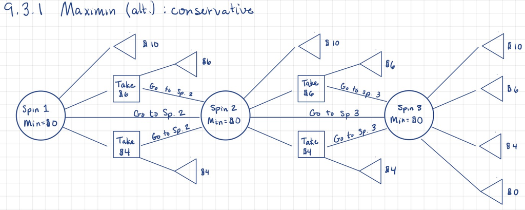

Decision tree for 9.3.1 using maximin criteria

## Problem 9.3.2

In 9.3.1 the probability of landing in the $0, $4, $5, and $10 sections are 0.23, 0.37, 0.15, and 0.25, respectively. We repeat the above calculations using new values of both the payoffs ($5, $10, $15, $20) and probabilities (0.25, 0.35, 0.28, 0.12).

```r
ev.spin3 <- sum(c(5, 10, 15, 20) * c(0.25, 0.35, 0.28, 0.12))
ev.spin3
```

```
## [1] 11.35
```

```r
ev.spin2 <- sum(c(ev.spin3,15,20) * c(0.6, 0.28, 0.12))
ev.spin2
```

```
## [1] 13.41
```

```r
ev.spin1 <- sum(c(ev.spin2,15,20) * c(0.6, 0.28, 0.12))
ev.spin1
```

```
## [1] 14.646
```

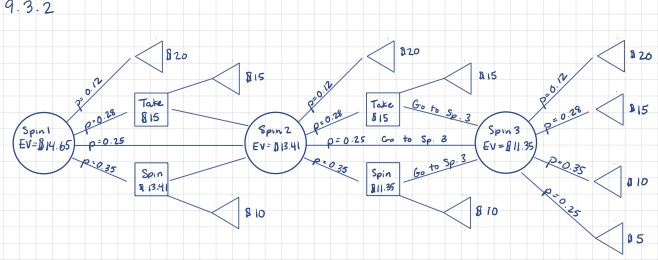

Decision tree for 9.3.2 using maximum expected value

### Alternative criterion: maximax

The expectation of the “maximum expected value” game at the beginning drops considerably from $14.65 down to $11.35! What about our maximax value rule?

```r
m.spin3 <- sum(c(5,10,15,20) * c(0.25, 0.35, 0.28, 0.12))
m.spin3
```

```
## [1] 11.35
```

```r
m.spin2 <- sum(c(m.spin3,20) * c(0.88, 0.12))
m.spin2
```

```
## [1] 12.388
```

```r
m.spin1 <- sum(c(m.spin2,20) * c(0.88, 0.12))
m.spin1
```

```
## [1] 13.30144
```

Yikes! This strategy is now considerably worse than the expectation rule ($13.30 vs $14.65). How has the variance changed?

```r
ve.spin3 <- sum(c(0.25, 0.35, 0.28, 0.12) * (c(5,10,15,20)-ev.spin3)^2)
ve.spin3
```

```
## [1] 23.4275
```

```r
ve.spin2 <- sum(c(0.6, 0.28, 0.12) * (c(ev.spin3,15,20)-ev.spin2)^2)
ve.spin2
```

```
## [1] 8.4654
```

```r
ve.spin1 <- sum(c(0.6, 0.28, 0.12) * (c(ev.spin2,15,20)-ev.spin1)^2)
ve.spin1
```

```
## [1] 4.391544
```

```r
vm.spin3 <- sum(c(0.25, 0.35, 0.28, 0.12) * (c(5,10,15,20)-m.spin3)^2)
vm.spin3
```

```
## [1] 23.4275
```

```r
vm.spin2 <- sum(c(0.88, 0.12) * (c(m.spin3,10)-m.spin2)^2)
vm.spin2
```

```
## [1] 1.632456
```

```r
vm.spin1 <- sum(c(0.88, 0.12) * (c(m.spin2,10)-m.spin1)^2)
vm.spin1
```

```
## [1] 2.042189
```

In this case we see that the maximax rule is less variable!

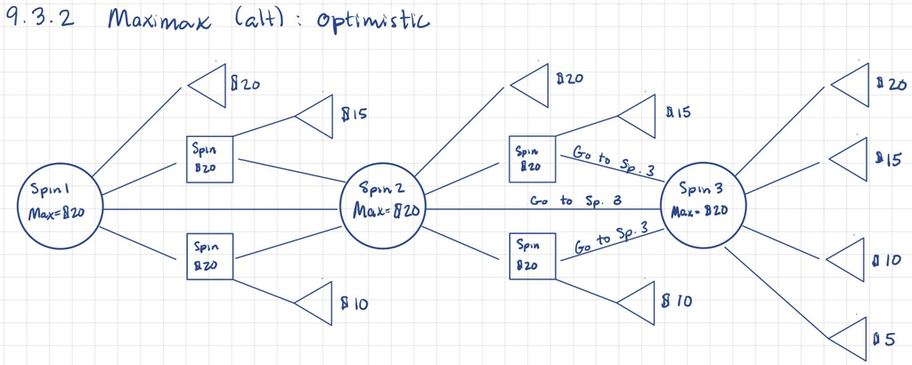

You’re optimistic! Keep trying… you’ll get that $20.

## Problem 9.3.5

The figure below gives a possible decision tree for this problem. Note that the dollar amounts are negative because we’re dealing with costs, which we want to minimize; by writing of them as negative quantity, we can just apply our usual maximization logic. (In other words, the maximum negative value is the minimum cost.)

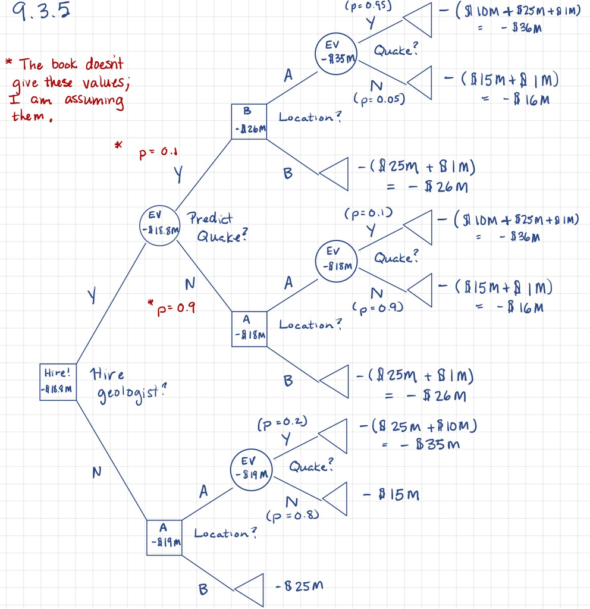

Decision tree

This problem is missing some information, namely the probability of the geologist predicting an earthquake at site A. In the figure, I just assumed a 90% chance that they predict “no earthquake.” We can clearly solve for where the break point is by solving $18p +26(1-p)=19$ which yields $p=0.875$. So, if the chance that the geologist predicts “no earthquake” is greater than 0.875, we would opt for hiring the geologist.

# Chapter 10

The problem in the homework asked you to solve for the optimal strategy in a 3-player, total conflict, game by using game theory (actually, the game is also a zero sum game). Specifically, you were told to find the best strategy for each player. Here are the payoffs—given as (Eddie’s payoff, Sara’s payoff, Tony’s payoff)—in the game:

**Given Tony (1)**:

|  | Sara (1) | Sara (2) |
| --- | --- | --- |
| **Eddie(1)** | (1, 1, -2) | (-4,3,1) |
| **Eddie(2)** | (2, -4, 2) | (-5,-5,10) |

**Given Tony (2)**:

|  | Sara (1) | Sara (2) |
| --- | --- | --- |
| **Eddie(1)** | (3, -2, -1) | (-6,-6,12) |
| **Eddie(2)** | (2, 2, -4) | (-2,3,-1) |

## Pure strategies

We can look at the movement diagram to figure out which strategies our players might choose:

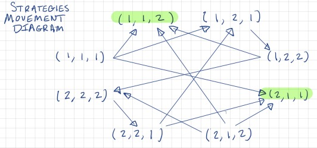

Movement diagram

In the diagram I highlighted the cases where Eddie, Sara, and Tony play either strategies 1, 1, and 2 (respectively) or 2, 1, and 1. As you can see the arrows all point *toward* these strategies. This indicates that our players cannot unilaterally move from these strategies and improve their situation; i.e., they are Nash equilibria. These strategies suggest that Sara will get stuck with strategy 1, but that either strategy 1 or 2 might work for Tony and Eddie depending on which strategy the other is playing. We might then consider a “mixed” strategy game. Note that Eddie gets a higher payoff and would prefer 1, 1, 2, while Tony gets a higher payoff at 2, 1, 1.

## Mixed Strategies

Because this game is a total conflict game, we can use a linear program to solve for the correct strategies. To do this, we write down the appropriate set of constraints for the players and solve.

### Eddie’s Game

Let’s call $x$ the proportion of time Eddie plays strategy 1; therefore $1-x$ is the proportion of time strategy 2 is played. We balance that against the four scenarios: Sara(1) Tony(1), Sara(1) Tony(2), Sara(2) Tony(1), and Sara(2) Tony(2). Here are the constraints for Eddie:

$$\mbox{Maximize} \quad P \quad \mbox{subject to} \\
P \le x + 2(1-x) \quad \mbox{(Sara(1), Tony(1))} \\
P \le 3 x + 2 (1-x) \quad \mbox{(Sara(1), Tony(2))} \\
P \le -4 x - 5 (1-x) \quad \mbox{(Sara(2), Tony(1))} \\
P \le -6 x - 2 (1-x) \quad \mbox{(Sara(2), Tony(2))} \\
x \ge 0 \\
x \le 1$$
We need to rewrite the system to look a bit more like our optimization problems we previously worked. Specifically, let’s simplify the equations and put $P$ and $x$ on the LHS of each equation. This yields:

$$P + x \le 2 \\
P - x \le 2 \\
P - x \le -5 \\
P + 4x \le -2 \\
x \le 1 \\
x \ge 0.$$
Note however that we do not have a non-negativity constraint on $P$; in fact, sometimes Eddie may get a payoff as low as $-6$. To correct this, define $Z = P + 10$ and maximize $Z$. I arbitrarily chose 10. **WHY IS THIS OKAY?** By making the substitution $P = Z - 10$, we get the new system:

$$Z + x \le 12 \\
Z - x \le 12 \\
Z - x \le 5 \\
Z + 4x \le 8 \\
x \le 1 \\
x,Z \ge 0,$$
which include the non-negativity constraint on $Z$.

Now we simply use our linear programming skills from Chapter 7 to find a solution. First, I will bring in my function that runs the Simplex algorithm:

```r
Simplex <- function(A, cost, x, Max = T, vals = F){

  Cols <- seq_len(ncol(A))
  B <- which(x!=0)
  N <- setdiff(Cols, B)
  out <- matrix(x, nrow = 1)

  enter <- 1

  while(! is.null(enter)){
    lambda <- solve(t(A[,B])) %*% cost[B]
    sn <- cost[N] - t(A[,N])%*% lambda #for maximization: continue as long as max(sn) > 0

    sn.pos <- sn[sn>0]
    sn.neg <- sn[sn<0]

    enter <- NULL

    if(Max & length(sn.pos > 0)) enter <- N[which.max(sn)]
    if(!Max & length(sn.neg > 0)) enter <- N[which.min(sn)]

    if( is.null(enter) ) break

    d <- solve(A[,B]) %*% A[,enter]
    ratios <- x[B]/d #get the ratios for the ratio test

    multiplier <- min(ratios[ratios > 0]) #value of entering variable
    exit <- B[which(ratios == multiplier)[1]]

    x[enter] <- multiplier
    x[B] <- x[B] - d*multiplier

    out <- rbind(out, x)

    B <- sort(union(setdiff(B, exit), enter))
    N <- setdiff(Cols, B)
  }

  rownames(out) <- NULL
  if(vals) return(out)

  return(out[nrow(out),])
}
```

Then we simply define the appropriate matrices, vectors, etc and run the algorithm:

```r
A <- c(1,1,1,0,0,0,0,
       1,-1,0,1,0,0,0,
       1,-1,0,0,1,0,0,
       1,4,0,0,0,1,0,
       0,1,0,0,0,0,1)

A <- matrix(A, nrow = 5, byrow = T)
C <- c(1,0,0,0,0,0,0)
x <- c(0,0,12,12,5,8,1)

Simplex(A,C,x)
```

```
## [1] 5.6 0.6 5.8 7.0 0.0 0.0 0.4
```

The solution is $Z = 5.6, x=0.6$ which transforms back to $P = -4.4, x = 0.6$. This tells us that Eddie’s best strategy is play strategy 1 60% of the time, guaranteeing a payoff of at least $-4.4$ on average. This matches the fact that Eddie would prefer the 1, 1, 2 equilibrium over the 2, 1, 1 equilibrium.

### Sara’s Game

We repeat the process above, but now writing down the system of constraints for Sara. Let $y$ be the percentage of time that Sara plays strategy 1, then:

$$\mbox{Maximize} \quad Z \quad \mbox{subject to} \\
Z + 2y \le 13 \\
Z - y \le 5 \\
Z - 4 y \le 4 \\
Z + y \le 13 \\
y \le 1 \\
y,Z \ge 0$$
where $Z$ is again the transformed payoff.

```r
A <- c(1,2,1,0,0,0,0,
       1,-1,0,1,0,0,0,
       1,-4,0,0,1,0,0,
       1,1,0,0,0,1,0,
       0,1,0,0,0,0,1)

A <- matrix(A, nrow = 5, byrow = T)
C <- c(1,0,0,0,0,0,0)
x <- c(0,0,13,5,4,13,1)

Simplex(A,C,x)
```

```
## [1] 6 1 5 0 2 6 0
```

Thus Sara has a pure strategy of playing 1, which will guarantee her of nothing worse than a $-4$ payoff. This matches what we found in our pure strategy analysis; Sara will play strategy 1.

### Tony’s Game

Now we write down the system of constraints for Tony. Let $z$ be the percentage of time that Tony plays strategy 1, then:

$$\mbox{Maximize} \quad Z \quad \mbox{subject to} \\
Z + z \le 9 \\
Z + 11 z \le 22 \\
Z - 6 z \le 6 \\
Z - 11 z \le 9 \\
z \le 1 \\
z,Z \ge 0$$
where $Z$ is again the transformed payoff.

```r
A <- c(1,1,1,0,0,0,0,
       1,11,0,1,0,0,0,
       1,-6,0,0,1,0,0,
       1,-11,0,0,0,1,0,
       0,1,0,0,0,0,1)

A <- matrix(A, nrow = 5, byrow = T)
C <- c(1,0,0,0,0,0,0)
x <- c(0,0,9,22,6,9,1)

Simplex(A,C,x)
```

```
## [1] 8.5714286 0.4285714 0.0000000 8.7142857 0.0000000 5.1428571 0.5714286
```